# CS 422

Kamen Petkov, Illinois Institute of Technology

## Homework-9 Practicum problems

### Import Libraries

```r
library(dplyr)
library(psych)
library(factoextra)
library(dbscan)
library(fpc)

setwd("C:/Users/ACER/Desktop/Desktop/IIT_Stuff/CS 422/myHws/HW9")
```

### 2.1 (a)

```r
df <- read.csv("s1.csv")
summary(df)
```

```
       x                y
 Min.   : 19835   Min.   : 51121
 1st Qu.:320352   1st Qu.:320108
 Median :505338   Median :526260
 Mean   :514938   Mean   :494709
 3rd Qu.:786229   3rd Qu.:713714
 Max.   :961951   Max.   :970756
```

```r
df.scale <- scale(df)
summary(df.scale)
```

```
       x                y
 Min.   :-2.025   Min.   :-1.881
 1st Qu.:-0.796   1st Qu.:-0.740
 Median :-0.039   Median : 0.134
 Mean   : 0.000   Mean   : 0.000
 3rd Qu.: 1.110   3rd Qu.: 0.929
 Max.   : 1.829   Max.   : 2.019
```

#### Standardization is useful when all of the features have a Gaussian/Normal distribution. Moreover, after observing that the min and max values from the summary are different, it makes sense to standardize the data. We will bring down the features to a common scale without distorting the difference in the range of values.

### 2.1 (b)

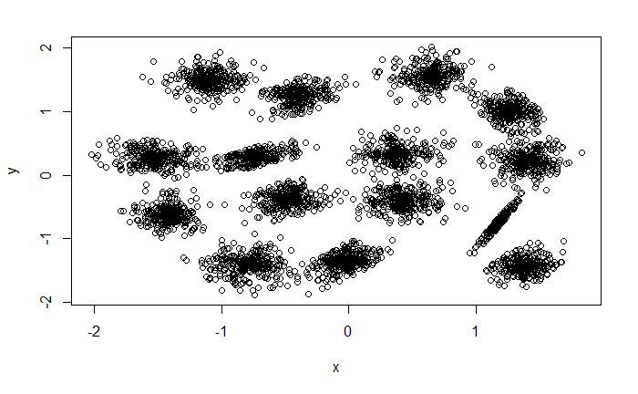

```r
# Plot the data
plot(df.scale)
```

#### After plotting the scaled data, we can see 15 well-separated clusters and a small number of outliers around the clusters.

### 2.1 (c)(i)

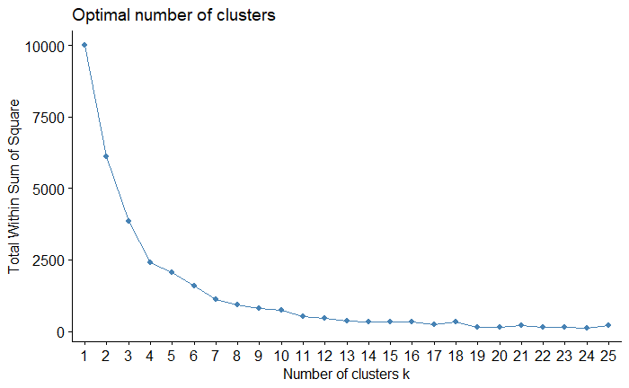

```r
# Number of clusters (k-means)
fviz_nbclust(df.scale, kmeans, k.max = 25, method="wss")
```

### 2.1 (c)(ii)

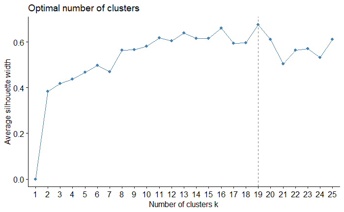

```r
fviz_nbclust(df.scale, kmeans, k.max = 25, method="silhouette")
```

### 2.1 (c)(iii)

#### The plots that we see after using the two methods (wss and silhouette) show us that the optimal number of clusters for k-means clustering is about 19 as afterward, there is little to no difference in the slope in both plots.

### 2.1 (d)(i)

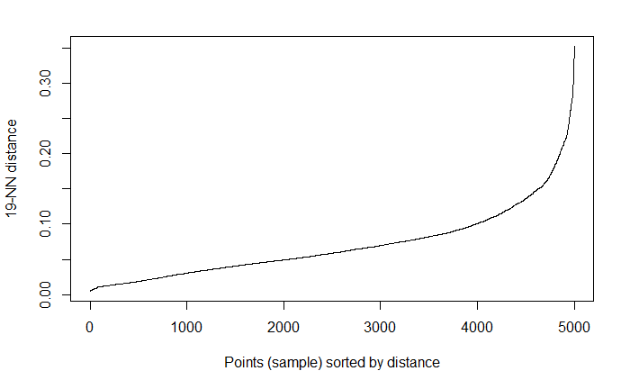

```r
kNNdistplot(df.scale, k = 19)
```

### 2.1 (e)(i)

#### I chose MinPts to be equal to 15. I first tried to follow the rule MinPts = 2 * number of dimension, however, the plot didn’t look good (MinPts was 4 since we have 2 dimensions.). Hence, I doubled MinPts. I noticed a little bit better but a similar result. Finally, I almost doubled this result as well and I noticed that when MinPts is equal to 15, I get the results that I wanted. For the most part, the outliers stay out of the clusters.

### 2.1 (e)(ii)

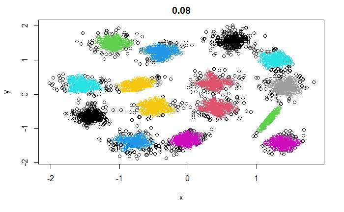

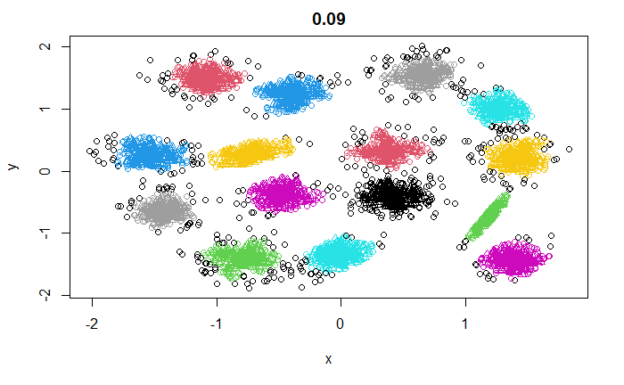

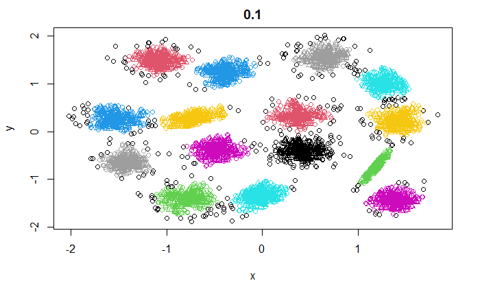

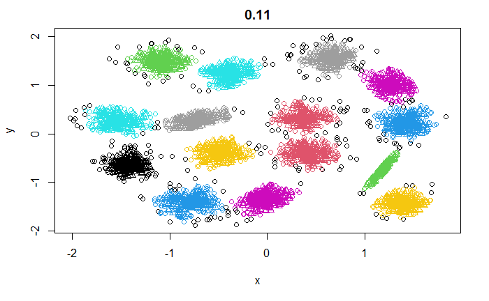

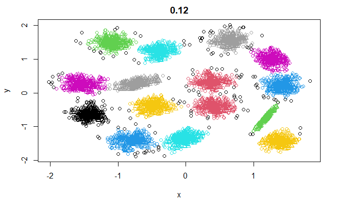

```r
# DBScan
for( i in c(0.08, 0.09, 0.1, 0.11, 0.12)){
  scan <- fpc::dbscan(df.scale, eps = i, MinPts = 15)
  plot(scan, df.scale, main = as.character(i))}
```

#### After plotting k-distances, I noticed that the knee is somewhere around eps = 0.08 and 0.12, as for these results the graph shows us that there are 14-15 clusters, the value that we were expecting.

#### At minPts = 15, eps = 0.08, there are 15 clusters.

#### At minPts = 15, eps = 0.09, there are 15 clusters.

#### At minPts = 15, eps = 0.10, there are 15 clusters.

#### At minPts = 15, eps = 0.11, there are 14 clusters.

#### At minPts = 15, eps = 0.12, there are 14 clusters.

### 2.2 (a)(i)

```r
df1 <- read.csv("countries.csv", row.names = 1)
summary(df1)
```

```
      GDP             HIV           Lifeexp          Mil          Oilcons           Pop            Tel
 Min.   : 3685   Min.   :0.100   Min.   :65.9   Min.   :0.50   Min.   : 0.80   Min.   :  33   Min.   : 44
 1st Qu.: 9640   1st Qu.:0.100   1st Qu.:72.6   1st Qu.:1.35   1st Qu.: 5.25   1st Qu.:  60   1st Qu.:241
 Median :27418   Median :0.300   Median :78.0   Median :2.50   Median :11.30   Median : 109   Median :433
 Mean   :22296   Mean   :0.413   Mean   :76.1   Mean   :2.25   Mean   :10.91   Mean   : 263   Mean   :391
 3rd Qu.:31832   3rd Qu.:0.650   3rd Qu.:79.8   3rd Qu.:2.70   3rd Qu.:15.10   3rd Qu.: 212   3rd Qu.:550
 Max.   :43369   Max.   :1.100   Max.   :82.0   Max.   :4.30   Max.   :25.10   Max.   :1322   Max.   :658
     Unempl
 Min.   : 2.90
 1st Qu.: 4.15
 Median : 6.60
 Mean   : 6.42
 3rd Qu.: 7.95
 Max.   :12.50
```

### 2.2 (a)(ii)

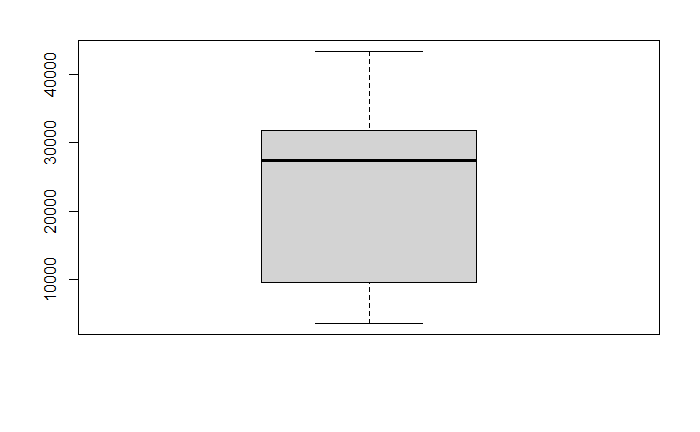

```r
boxplot(df1$GDP)
```

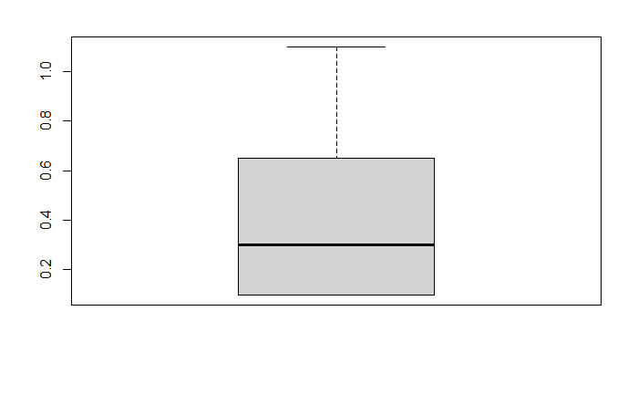

```r
boxplot(df1$HIV)
```

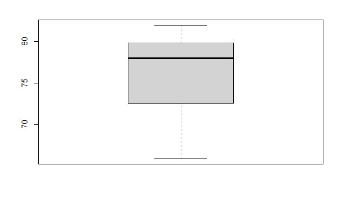

```r
boxplot(df1$Lifeexp)
```

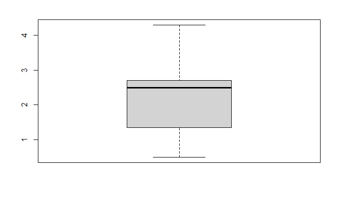

```r
boxplot(df1$Mil)
```

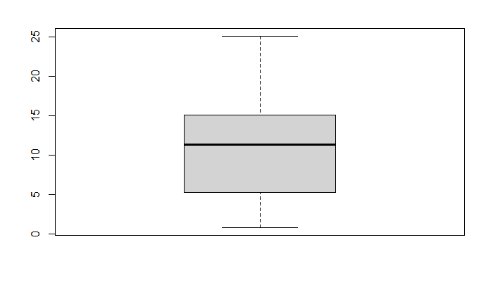

```r
boxplot(df1$Oilcons)
```

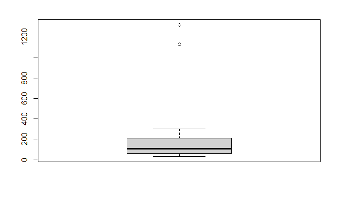

```r
boxplot(df1$Pop)
```

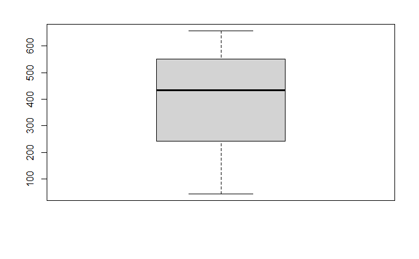

```r
boxplot(df1$Tel)
```

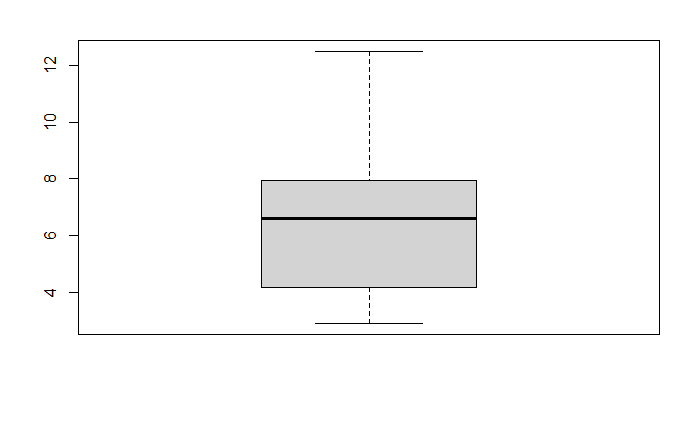

```r
boxplot(df1$Unempl)
```

#### PCA transforms datasets from high dimensions to low dimensions with a minimal loss of data. However, here we notice that if we consider the population of China and India (which is too big), it would affect the transformation (it’s not going to apply for the general case). Hence, these two countries’ populations are considered outliers.

### 2.2 (b)(i)

```r
# PCA
options(digits = 3)
df1
```

|  | GDP | HIV | Lifeexp | Mil | Oilcons | Pop | Tel | Unempl |
| --- | --- | --- | --- | --- | --- | --- | --- | --- |
| Brazil | 8710 | 0.7 | 72.2 | 2.6 | 4.0 | 190 | 204.2 | 9.6 |
| Canada | 35370 | 0.3 | 80.3 | 1.1 | 25.1 | 33 | 622.3 | 6.4 |
| China | 7724 | 0.1 | 72.9 | 4.3 | 1.8 | 1322 | 278.4 | 4.2 |
| France | 29852 | 0.4 | 80.6 | 2.6 | 11.3 | 64 | 543.5 | 8.7 |
| Germany | 31941 | 0.1 | 79.0 | 1.5 | 11.7 | 82 | 657.8 | 7.1 |
| India | 3685 | 0.9 | 68.6 | 2.5 | 0.8 | 1130 | 44.0 | 7.8 |
| Indonesia | 4041 | 0.1 | 70.2 | 3.0 | 1.8 | 235 | 63.2 | 12.5 |
| Italy | 30199 | 0.5 | 79.9 | 1.8 | 11.8 | 58 | 430.8 | 7.0 |
| Japan | 33100 | 0.1 | 82.0 | 0.8 | 16.0 | 127 | 432.8 | 4.1 |
| Mexico | 10570 | 0.3 | 75.6 | 0.5 | 6.6 | 109 | 182.7 | 3.2 |

[output cut: 5 more lines]

```r
p <- prcomp(df1, scale = T)
summary(p)
```

```
Importance of components:
                         PC1   PC2   PC3    PC4   PC5    PC6    PC7    PC8
Standard deviation     2.060 1.138 1.017 0.8690 0.593 0.4173 0.3323 0.1833
Proportion of Variance 0.531 0.162 0.129 0.0944 0.044 0.0218 0.0138 0.0042
Cumulative Proportion  0.531 0.693 0.822 0.9162 0.960 0.9820 0.9958 1.0000
```

#### The summary shows that 4 of the components explain at least 90% of the variance (91.62%).

### 2.2 (b)(ii)

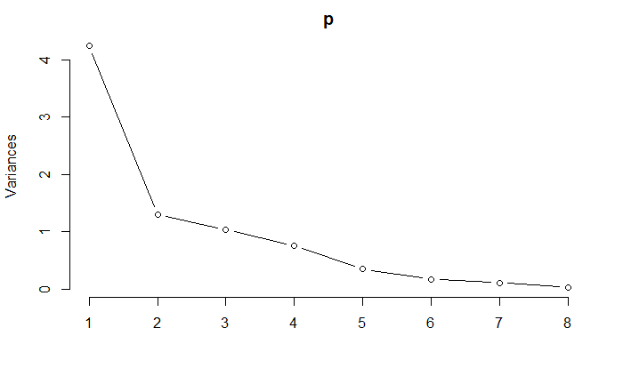

```r
# Screeplot
screeplot(p, type = "lines")
```

### 2.2 (b)(iii)

#### Based on the screeplot I would use 5 components for the modeling because after the 5th component there isn’t much of a change in the slope.

### 2.2 (c)

```r
# PCA components
p$rotation
```

```
           PC1     PC2      PC3     PC4     PC5     PC6    PC7     PC8
GDP      0.456  0.0636 -0.27109 -0.0544  0.1495 -0.0800  0.147  0.8132
HIV     -0.193 -0.3280 -0.69422  0.4840  0.1955 -0.2380  0.146 -0.1505
Lifeexp  0.441  0.0145  0.18765 -0.1449  0.4481 -0.2483  0.568 -0.4047
Mil     -0.196  0.5671 -0.48008 -0.4163 -0.3252 -0.0500  0.334 -0.1275
Oilcons  0.428  0.0364 -0.32045  0.0465  0.0784  0.7889 -0.118 -0.2617
Pop     -0.315  0.5419  0.00664  0.0798  0.7264  0.0526 -0.258  0.0601
Tel      0.442  0.1409 -0.20009 -0.1121 -0.0727 -0.4944 -0.647 -0.2519
Unempl  -0.210 -0.5017 -0.19001 -0.7399  0.3064  0.0571 -0.152  0.0208
```

### 2.2 (c)(i)

#### In PC1 GDP, Life Expectancy, Oil consumption, and telephone lines are positively correlated, while the other components (HIV, Military Spending, Population, and Unemployment) are negatively correlated.

### 2.2 (c)(ii)

#### In PC2 GDP, Life expectancy, Military Spending, Oil consumption, Population, Telephone lines are positively correlated, while HIV and Unemployment are negatively correlated.

### 2.2 (d)

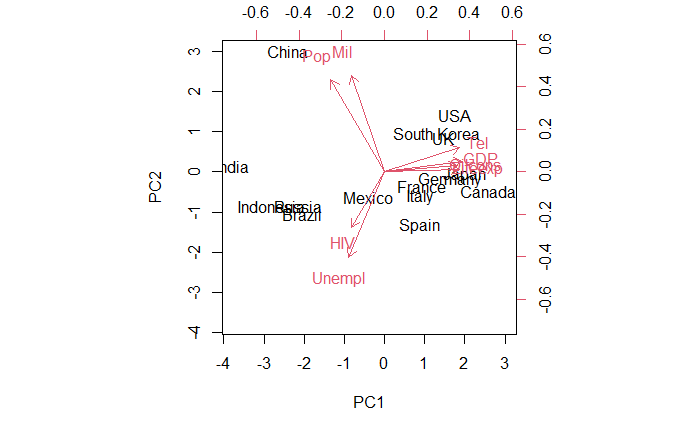

```r
# Draw a biplot
p.ranked <- prcomp(df1, scale = T, rank. = 2)
biplot(p, scale=0)
```

### 2.2 (d)(i)

```r
p.ranked$x
```

```
               PC1     PC2
Brazil      -2.037 -1.0400
Canada       2.589 -0.4765
China       -2.386  3.0030
France       0.952 -0.3416
Germany      1.638 -0.1929
India       -3.767  0.1503
Indonesia   -2.784 -0.8425
Italy        0.900 -0.6217
Japan        2.013 -0.0574
Mexico      -0.402 -0.6190
Russia      -2.143 -0.8383
South Korea  1.319  0.9784
Spain        0.896 -1.3434
UK           1.457  0.8345
USA          1.755  1.4071
```

### 2.2 (d)(ii)

```r
mat.p <- matrix(p.ranked$x[c(1,14,9),], nrow = 3, ncol = 2)
m.rot <- matrix(p$rotation, nrow = 8, ncol = 2)
dot.prod <- mat.p %*% t(m.rot)

rownames(dot.prod) <- c("Brazil", "UK", "Japan")
colnames(dot.prod) <- c("GDP", "HIV", "Lifeexp", "Mil", "Oilcons", "Pop", "Tel", "Unempl")
dot.prod
```

```
          GDP    HIV Lifeexp    Mil Oilcons      Pop    Tel Unempl
Brazil -0.995  0.735  -0.913 -0.189  -0.909  0.07812 -1.048  0.950
UK      0.718 -0.556   0.654  0.187   0.653 -0.00679  0.762 -0.725
Japan   0.914 -0.371   0.887 -0.428   0.859 -0.66524  0.882 -0.394
```

```r
scale(df1[c(1,14,9),])
```

```
          GDP    HIV Lifeexp    Mil Oilcons     Pop    Tel Unempl
Brazil -1.153  1.141  -1.090  0.676  -1.051  0.9922 -1.086  1.138
UK      0.526 -0.415   0.214  0.473   0.111 -1.0077  0.882 -0.737
Japan   0.627 -0.726   0.876 -1.149   0.940  0.0155  0.204 -0.401
attr(,"scaled:center")
     GDP      HIV  Lifeexp      Mil  Oilcons      Pop      Tel   Unempl
2.45e+04 3.33e-01 7.76e+01 1.93e+00 1.03e+01 1.26e+02 3.97e+02 5.53e+00
attr(,"scaled:scale")
     GDP      HIV  Lifeexp      Mil  Oilcons      Pop      Tel   Unempl
1.37e+04 3.21e-01 4.99e+00 9.87e-01 6.03e+00 6.45e+01 1.77e+02 3.57e+00
```